# Logístico

[figure not shown]

Autores

Correo

Valentina Díaz Torres

Valentina.diaz@cunef.edu

Francisco del Val Yague

Francisco.delval@cunef.edu

Alejandro García Girón

A.garciagiron@cunef.edu

```
Index(['member_id', 'loan_amnt', 'funded_amnt', 'funded_amnt_inv', 'term',
       'int_rate', 'installment', 'emp_length', 'home_ownership', 'annual_inc',
       ...
       'hardship_payoff_balance_amount', 'hardship_last_payment_amount',
       'disbursement_method', 'debt_settlement_flag',
       'debt_settlement_flag_date', 'settlement_status', 'settlement_date',
       'settlement_amount', 'settlement_percentage', 'settlement_term'],
      dtype='object', length=134)
Las columna son iguales
Las columna son iguales
Las columna son iguales
Las columna son iguales
Las columna son iguales
Las columna son iguales
Las columna son iguales
term
pymnt_plan
initial_list_status
application_type
hardship_flag
disbursement_method
debt_settlement_flag
```

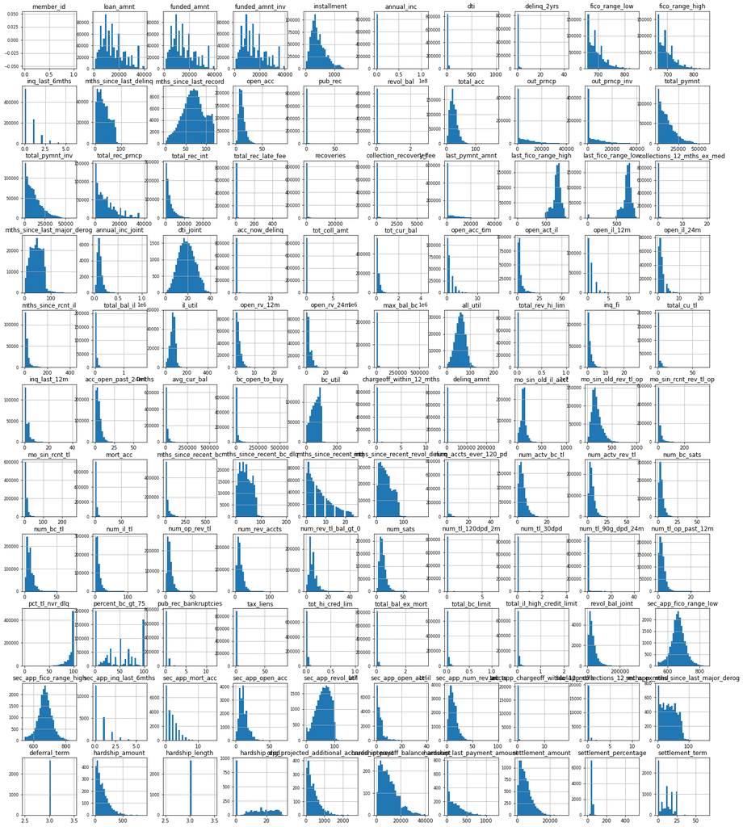

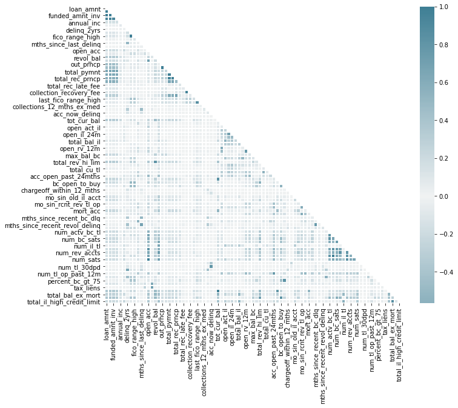

```python
import sys
sys.path.append("../00_eda_ingeniera_variables")
from eda_ingenieria_de_variable import *
```

## Regresión Logística

La Regresión Logística es una técnica de aprendizaje automático para clasificación. Es una red neuronal en miniatura. De hecho, la regresión logística, se trata de una red neuronal con exactamente una neurona. Graficamente la podemos ver a continuación:

[figure not shown]

### Carga de librerías

```python
# manipulación del dataframe
import numpy as np
import pandas as pd

# Gráficos
import seaborn as sns
import matplotlib.pyplot as plt
from matplotlib import pyplot

#sklearn
from sklearn.linear_model import LogisticRegression
from sklearn import metrics
from sklearn.metrics import confusion_matrix, plot_confusion_matrix, classification_report, roc_auc_score, roc_curve
from sklearn.model_selection import train_test_split
from sklearn.dummy import DummyClassifier
from sklearn.metrics import accuracy_score
import itertools

#para guardar modeos
import pickle
import random
random.seed(1984)

#import bucket as Lb
```

**Training - Test**

```python
#Separamos la variable target del resto del dataset
X = data.drop(['loan_status_Paga'],axis=1)

#Analogamente que arriba pero esta vez obviamos el resto de la target
Y = data['loan_status_Paga']
```

```python
#Con esta función separamos la parte de train y test
X_train, X_test, Y_train, Y_test = train_test_split(X, Y, test_size = 0.2)
```

### Modelo Base

Antes de comenzar con la evaluación de los modelos propuestos generamos un modelo base que nos indicara cual es la proporción entre ceros y unos de nuestra variable target y poder tener un modelo básico a tener en cuenta ya que conocemos la distribución a priori.

```python
#Modelo básico
modelobase = DummyClassifier(strategy='most_frequent', random_state=1984)

# Entrenamiento del modelo
modelobase.fit(X_train, Y_train)
```

```
DummyClassifier(random_state=1984, strategy='most_frequent')
```

```python
# Prediccion
predbase = modelobase.predict(X_test)
print(predbase)
```

```
[1 1 1 ... 1 1 1]
```

```python
# Check its accuracy
accuracy_score(Y_test, predbase)
```

```
0.7453780330812753
```

### Regresión Logística

```python
#Creamos el modelo con la función LogosticRegression
logistica = LogisticRegression()

#Entrenamiento del modelo
logistica.fit(X_train, Y_train)
```

```
LogisticRegression()
```

#### Predicción

```python
#predecimos
pred = logistica.predict(X_test)

#En el print del resultado 0 sería no concedido y 1 sería concedido
print(pred)
```

```
[1 1 1 ... 1 1 1]
```

```python
#Comprobamos el modelo
accuracy_score(Y_test, pred)
```

```
0.7452049459643657
```

#### Matrices de confusion

La matriz de confusión es una herramienta fundamental a la hora de evaluar el desempeño de un algoritmo de clasificación, ya que dará una mejor idea de cómo se está clasificando dicho algoritmo, a partir de un conteo de los aciertos y errores de cada una de las clases en la clasificaión. Así se puede comprobar si el algoritmo está clasificando mal las clases y en qué medida.

```python
confusion_matrix(Y_test, pred)
```

```
array([[   18, 23519],
       [   34, 68868]], dtype=int64)
```

##### Matriz de confusión

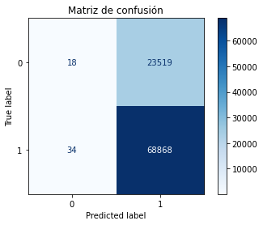

```python
disp = plot_confusion_matrix(logistica, X_test, Y_test,
                                 #display_labels= Y,
                                 cmap=plt.cm.Blues);
disp.ax_.set_title('Matriz de confusión');
```

##### Matriz de confusión normalizada

A diferencia de la anterior que nos expresa el número por casos esta nos los devuelve en tanto por uno lo cual se presenta como más intuitivo

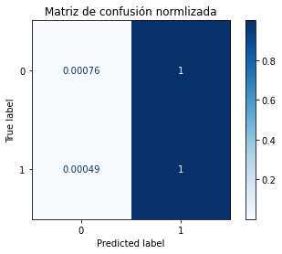

```python
disp = plot_confusion_matrix(logistica, X_test, Y_test,
                                 #display_labels= Y,
                                 cmap=plt.cm.Blues,
                                 normalize= 'true');
disp.ax_.set_title('Matriz de confusión normlizada');
```

#### Curva ROC

Esta es una representación gráfica de la sensibilidad frente a la especificidad para un sistema clasificador binario según se varía el umbral de discriminación.

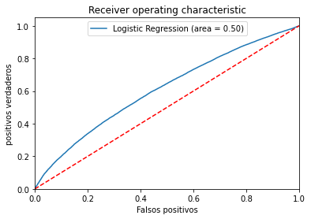

```python
logit_roc_auc = roc_auc_score(Y_test, logistica.predict(X_test))
fpr, tpr, thresholds = roc_curve(Y_test, logistica.predict_proba(X_test)[:,1])
plt.figure()
plt.plot(fpr, tpr, label='Logistic Regression (area = %0.2f)' % logit_roc_auc)
plt.plot([0, 1], [0, 1],'r--')
plt.xlim([0.0, 1.0])
plt.ylim([0.0, 1.05])
plt.xlabel('Falsos positivos')
plt.ylabel('positivos verdaderos')
plt.title('Receiver operating characteristic')
plt.legend(loc="upper center")
plt.savefig('Log_ROC')
```

#### EstadÍsticos del modelo

```python
print(classification_report(Y_test, pred))
```

```
              precision    recall  f1-score   support

           0       0.35      0.00      0.00     23537
           1       0.75      1.00      0.85     68902

    accuracy                           0.75     92439
   macro avg       0.55      0.50      0.43     92439
weighted avg       0.64      0.75      0.64     92439
```

```python
#Guardamos el modelo
model = logistica
filename = 'logistic_model.sav'
pickle.dump(model, open(filename, 'wb'))
```